# 長崎大学経済学部宇都宮研究室

Management by Visualizing the Invisible Stock of Human Resources / Inclusive Mobility / Socio-ecological Systems

# 👋 概要

宇都宮研究室は、**インクルーシブ・モビリティ**、**衛星画像情報を用いた人的資源量推定**、**社会‐生態システム**を横断する研究に取り組んでいます。

## 📰 お知らせ

- 2025-09-12 新サイト試験公開。レイアウトのフィードバック歓迎です。

## 学術業績

[Researchmap](https://researchmap.jp/yuzuruu)参照。

## ゼミナール案内

宇都宮研究室へようこそ

## 🔬 研究トピック

研究室の最近の主題は次の3つです。

- 造船業における作業と熟練その他いろいろ ：若くないとできなかった研究。若かったワタクシを受け入れてくださった方々に記して謝意を表します。
- 衛星情報を用いた人的資源量推定：人的資源は、ある地域に分布する働けそうな人々の数。たのしい統計的推論とたのしい現地調査@タイとを組み合わせるたのしい研究。35,000歩/日歩く。暑い。2kg/日痩せます。調査が終わればリバウンド。ห้องน้ำอยู่ที่ไหนครับ。
- ベトナムおよびカンボジアにおける生態系サービス推定：水産学部と環境科学部と共同研究。淡水フグはおいしいよ。
  - その他色々：車椅子にGPSとカメラを取り付けて、車椅子観光客を阻むものはなにで、どう移動に影響するか解明してます。意外な結果を得て、これはまたびっくり。

**ヒント**

**方法論の特徴**：RとStan（cmdstanr）による階層ベイズ、空間ラグ／誤差の実装など統計学的知見と、地べたを這って集めたデータを組み合わせるのです（図 1）。

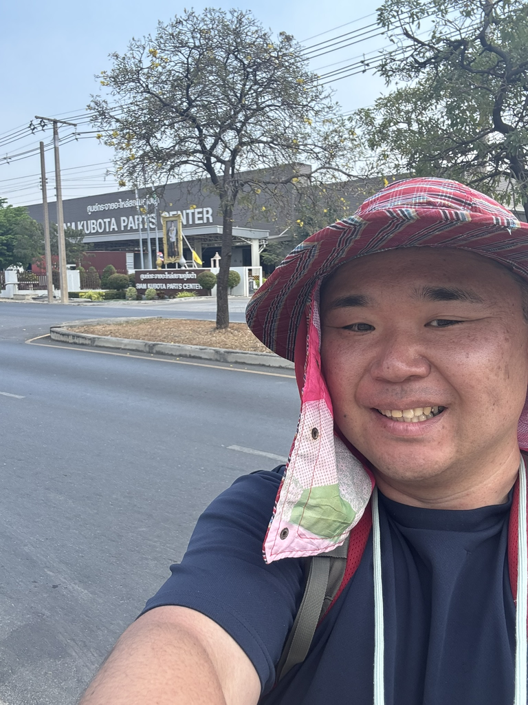

図 1: 2025年2月ナワナコン工業団地にて。ひたすら歩き回って35,000歩。今日も元気だお水がうまい。

## 📚 論文・データ・コード

[researchmap](https://researchmap.jp/yuzuruu) [Github](https://github.com/yuzuruu)

## 👥 メンバー

- 教員：宇都宮 譲（Ph.D.）
- 学生・協力研究者：

## 🧭 参加・見学

- ジャーナルクラブ（労務管理・HRM）：月1回／オンライン併用
- データ演習（R / Quarto / Stan）：不定期
- 見学・共同研究の相談はメールにてご連絡ください。

## 📍 アクセス

長崎大学経済学部  
4-2-1 Katafuchi, Nagasaki, Japan  
E-mail: yuzuru@nagasaki-u.ac.jp

## 予定

[interactive chart not shown]

3. 2025 Yuzurulab